# Prediction Assignment Writeup

Sergio Paz

18 de diciembre de 2017

## Background

Using devices such as Jawbone Up, Nike FuelBand, and Fitbit it is now possible to collect a large amount of data about personal activity relatively inexpensively. These type of devices are part of the quantified self movement – a group of enthusiasts who take measurements about themselves regularly to improve their health, to find patterns in their behavior, or because they are tech geeks. One thing that people regularly do is quantify how much of a particular activity they do, but they rarely quantify how well they do it. In this project, your goal will be to use data from accelerometers on the belt, forearm, arm, and dumbell of 6 participants. They were asked to perform barbell lifts correctly and incorrectly in 5 different ways. More information is available from the website here: http://web.archive.org/web/20161224072740/http:/groupware.les.inf.puc-rio.br/har (see the section on the Weight Lifting Exercise Dataset).

## Data

Data source for the project: http://web.archive.org/web/20161224072740/http:/groupware.les.inf.puc-rio.br/har

The training data for this project are available here:

https://d396qusza40orc.cloudfront.net/predmachlearn/pml-training.csv

The test data are available here:

https://d396qusza40orc.cloudfront.net/predmachlearn/pml-testing.csv

## Reading data

First, download data file in your R work directory. Check if you can read the files and see the dimension.

```r
train <- read.csv("pml-training.csv")
test <- read.csv("pml-testing.csv")
dim(train); dim(test)
```

```
## [1] 19622   160
```

```
## [1]  20 160
```

Load the libraries that you need.

```r
library(knitr)
library(caret)
```

```r
library(corrplot)
```

Split dataset: 70% training and 30% testing.

```r
inTrain <- createDataPartition(train$classe, p=0.7, list = FALSE)
TrainSet <- train[inTrain, ]
TestSet <- train[-inTrain, ]
dim(TrainSet); dim(TestSet)
```

```
## [1] 13737   160
```

```
## [1] 5885  160
```

## Cleaning data

Cleaning data from dataset: 1. Eliminate NA values 2. Remove variables using Near Zero Variance 3. Remove ID in variables

After all steps, you can see the number of variables for the analysis.

```r
dataNZV <- nearZeroVar(TrainSet)
TrainSet <- TrainSet[, -dataNZV]
TestSet <- TestSet[, -dataNZV]
dim(TestSet); dim(TrainSet)
```

```
## [1] 5885  109
```

```
## [1] 13737   109
```

```r
dataNA <- sapply(TrainSet, function(x) mean(is.na(x))) > 0.95
TrainSet <- TrainSet[, dataNA==FALSE]
TestSet <- TestSet[, dataNA==FALSE]
dim(TestSet); dim(TrainSet)
```

```
## [1] 5885   59
```

```
## [1] 13737    59
```

```r
TrainSet <- TrainSet[, -(1:5)]
TestSet <- TestSet[, -(1:5)]
dim(TestSet); dim(TrainSet)
```

```
## [1] 5885   54
```

```
## [1] 13737    54
```

Printing correlation between variables. Strong correlation is visible in dark colors.

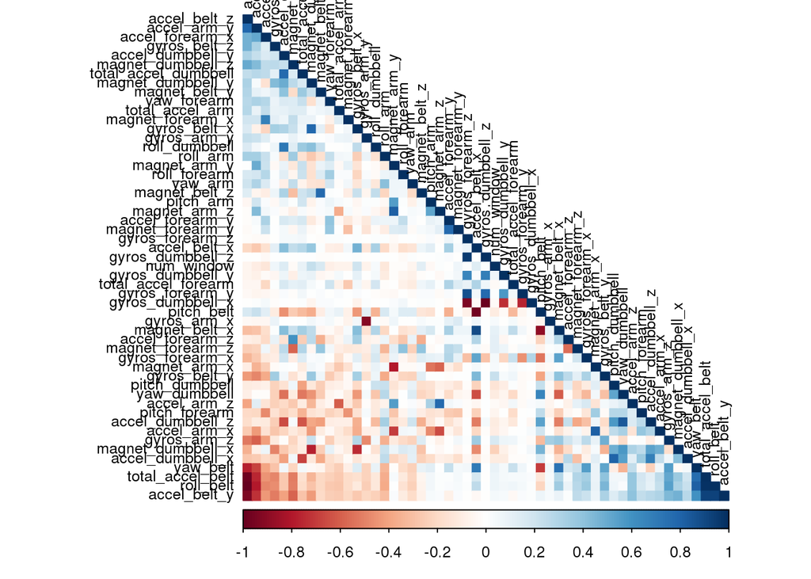

```r
correlationMatrix <- cor(TrainSet[, -54])
corrplot(correlationMatrix, order = "FPC", method = "color", type = "lower", tl.cex = 0.8, tl.col = rgb(0, 0, 0))
```

## Prediction model

Create predicction model using random forest.

Load libraries.

```r
library(parallel)
library(doParallel)
cl <- makeCluster(detectCores() -1)
registerDoParallel(cl)
```

Control parameters

```r
ctrl <- trainControl(classProbs = TRUE, savePredictions = TRUE, allowParallel = TRUE)
```

Fit model

```r
method <- "rf"
system.time(TrainingModel <- train(classe ~ ., data = TrainSet, method=method))
```

```
##     user   system  elapsed
##   44.368    0.117 2211.807
```

Stop the clusters.

```r
stopCluster(cl)
```

## Evaluate the model

To see the model with training data set.

```r
TrainingModel
```

```
## Random Forest
##
## 13737 samples
##    53 predictor
##     5 classes: 'A', 'B', 'C', 'D', 'E'
##
## No pre-processing
## Resampling: Bootstrapped (25 reps)
## Summary of sample sizes: 13737, 13737, 13737, 13737, 13737, 13737, ...
## Resampling results across tuning parameters:
##
##   mtry  Accuracy   Kappa
##    2    0.9917427  0.9895542
##   27    0.9956609  0.9945114
##   53    0.9892703  0.9864275
##
## Accuracy was used to select the optimal model using  the largest value.
## The final value used for the model was mtry = 27.
```

Confusion matrix method shows accuracy, sensitivity & specificity metrics.

```r
hat <- predict(TrainingModel, TrainSet)
confusionMatrix(hat, TrainSet[, "classe"])
```

```
## Confusion Matrix and Statistics
##
##           Reference
## Prediction    A    B    C    D    E
##          A 3906    0    0    0    0
##          B    0 2658    0    0    0
##          C    0    0 2396    0    0
##          D    0    0    0 2252    0
##          E    0    0    0    0 2525
##
## Overall Statistics
##
##                Accuracy : 1
##                  95% CI : (0.9997, 1)
##     No Information Rate : 0.2843
##     P-Value [Acc > NIR] : < 2.2e-16
##
##                   Kappa : 1
##  Mcnemar's Test P-Value : NA
##
## Statistics by Class:
##
##                      Class: A Class: B Class: C Class: D Class: E
## Sensitivity            1.0000   1.0000   1.0000   1.0000   1.0000
## Specificity            1.0000   1.0000   1.0000   1.0000   1.0000
## Pos Pred Value         1.0000   1.0000   1.0000   1.0000   1.0000
## Neg Pred Value         1.0000   1.0000   1.0000   1.0000   1.0000
## Prevalence             0.2843   0.1935   0.1744   0.1639   0.1838
## Detection Rate         0.2843   0.1935   0.1744   0.1639   0.1838
## Detection Prevalence   0.2843   0.1935   0.1744   0.1639   0.1838
## Balanced Accuracy      1.0000   1.0000   1.0000   1.0000   1.0000
```

## Evaluate the model

```r
hat <- predict(TrainingModel, TestSet)
confusionMatrix(hat, TestSet[, "classe"])
```

```
## Confusion Matrix and Statistics
##
##           Reference
## Prediction    A    B    C    D    E
##          A 1673    5    0    0    0
##          B    1 1130    0    0    0
##          C    0    4 1026    2    0
##          D    0    0    0  962    2
##          E    0    0    0    0 1080
##
## Overall Statistics
##
##                Accuracy : 0.9976
##                  95% CI : (0.996, 0.9987)
##     No Information Rate : 0.2845
##     P-Value [Acc > NIR] : < 2.2e-16
##
##                   Kappa : 0.997
##  Mcnemar's Test P-Value : NA
##
## Statistics by Class:
##
##                      Class: A Class: B Class: C Class: D Class: E
## Sensitivity            0.9994   0.9921   1.0000   0.9979   0.9982
## Specificity            0.9988   0.9998   0.9988   0.9996   1.0000
## Pos Pred Value         0.9970   0.9991   0.9942   0.9979   1.0000
## Neg Pred Value         0.9998   0.9981   1.0000   0.9996   0.9996
## Prevalence             0.2845   0.1935   0.1743   0.1638   0.1839
## Detection Rate         0.2843   0.1920   0.1743   0.1635   0.1835
## Detection Prevalence   0.2851   0.1922   0.1754   0.1638   0.1835
## Balanced Accuracy      0.9991   0.9959   0.9994   0.9988   0.9991
```

## Final model

The estimate error is less than 1%

```r
varImp(TrainingModel)
```

```
## rf variable importance
##
##   only 20 most important variables shown (out of 53)
##
##                      Overall
## num_window           100.000
## roll_belt             68.047
## pitch_forearm         40.743
## yaw_belt              31.938
## magnet_dumbbell_y     30.745
## pitch_belt            29.249
## magnet_dumbbell_z     29.223
## roll_forearm          26.032
## accel_dumbbell_y      13.477
## roll_dumbbell         11.486
## magnet_dumbbell_x     10.691
## accel_forearm_x       10.645
## total_accel_dumbbell   9.427
## accel_belt_z           8.746
## accel_dumbbell_z       8.196
## magnet_belt_y          7.711
## magnet_belt_z          7.684
## magnet_forearm_z       7.410
## magnet_belt_x          5.983
## roll_arm               5.591
```

```r
TrainingModel$finalModel
```

```
##
## Call:
##  randomForest(x = x, y = y, mtry = param$mtry)
##                Type of random forest: classification
##                      Number of trees: 500
## No. of variables tried at each split: 27
##
##         OOB estimate of  error rate: 0.25%
## Confusion matrix:
##      A    B    C    D    E  class.error
## A 3904    1    0    0    1 0.0005120328
## B    6 2649    2    1    0 0.0033860045
## C    0    8 2387    1    0 0.0037562604
## D    0    0    6 2245    1 0.0031083481
## E    0    1    0    7 2517 0.0031683168
```